**Byungju Kim** Ph.D.  
Research Scientist / Bioinformatics Team  
# 291 Harmony-ro, Yeonsu-gu, Incheon  
mobile : +82-10-5091-8731  
email : byungju.kim@edgc.com

[figure not shown]

##### Chapter 4 : Modeling and its evaluation Author : Byungju Kim Date : 2018-10-17

# 1 Objectives of the chapter

- Learn how to fit the model. (how to select good model)
  - Least Square
  - Gradient Descent
  - Batch Gradient Descent
  - Stochastic Gradient Descent
- Understanding learning rate and curve.
- Learn some regression models, such as
  - Lienar Regression
  - Polynominal Regression
  - biased regression, such as ridge, lasso and elastic net.

# 2 Linear Regression

Simple linear regression (SLR) is an approach for predicting a quantitative response (dependent variables,ouput) using a single feature (single predictor or input variables). simple linear regression fits a straight line to the data.

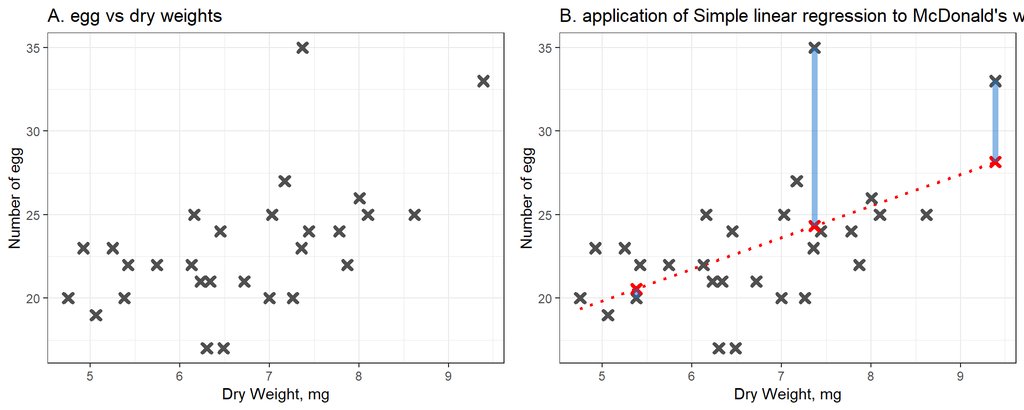

Figure 2.1: **Relationship between dry weight and number of eggs female *Platorchestia platensis*,a kind of sand flea, carrying**. suppose that we are interesting in the relationship between female weight and the number of eggs.

```r
egg<-c(20,23,22,20,25,25,17,24,20,27,24,21,22,22,23,35,26,23,25,24,19,21,20,33,17,21,25,22)
weight<-c(5.38,7.36,6.13,4.75,8.10,8.62,6.30,7.44,7.26,7.17,7.78,6.23,5.42,7.87,5.25,7.37,8.01,4.92,7.03,6.45,5.06,6.72,7.00,9.39,6.49,6.34,6.16,5.74)

df <- data.frame(egg=egg,weight=weight,pred_egg=10.386+weight*1.892)

p1<-ggplot(df,aes(weight,egg)) # geom_smooth(method=lm,linetype="dotted")
p1<-p1+ geom_point(shape=4,stroke=2,color="grey31") + theme_bw() +xlab("Dry Weight, mg") + ylab("Number of egg")
p1<-p1+ggtitle("A. egg vs dry weights")

p2<-ggplot(df,aes(weight,egg)) + geom_smooth(method=lm,linetype="dotted",se=FALSE,color="red")
p2<-p2+ geom_point(shape=4,stroke=2,color="grey31") + theme_bw() +xlab("Dry Weight, mg") + ylab("Number of egg")
p2<-p2+geom_point(data=df[c(1,16,24),],aes(weight,pred_egg),color="red",stroke=2,shape=4)
p2<-p2+annotate("segment",x=5.38,xend=5.38,y=20,yend=20.56496,color="dodgerblue3",size=2,alpha=0.5)
p2<-p2+annotate("segment",x=7.37,xend=7.37,y=24.33004,yend=35,color="dodgerblue3",size=2,alpha=0.5)
p2<-p2+annotate("segment",x=9.39,xend=9.39,y=33,yend=28.15188,color="dodgerblue3",size=2,alpha=0.5)
p2<-p2+ggtitle("B. application of Simple linear regression to McDonald's work (1980)")

grid.arrange(p1,p2,ncol=2)
```

We can grasp that the increment of Dry weight increases the number of eggs carrying.

The distances, indicating a thick blue line, between black x and red x is unpredicted proportion from the hypothesis.

$$\begin{equation}
\begin{aligned}
Y &= H_{0}(x) + \epsilon \\
&= \hat{Y} + \epsilon \\
&= \theta_{0} + \theta_{1} x + \epsilon
\end{aligned}
\tag{2.1}
\end{equation}$$

the equation is also written as follows :

$$\begin{equation}
\hat{Y} = \Theta^{T} \cdot X
\tag{2.2}
\end{equation}$$

## 2.1 Cost(Loss) function for Linear Regression

- **Mean Absolute Error** (=L1 Loss)

  Mean Absolute Error (MAE) is the sum of absolute differences between our prediction and ground truth. it measures average error in a set of prediction, by ignoring the direction of errors.

$$MAE = \sum_{i=1}^{n} \frac{|\hat{y}_{i}-y_{i}|}{n}$$

- **Mean Squared Error** (=L2 Loss)

  Mean Square Error (MSE) is the sum of our prediction’s squared error from the ground truth.

$$MSE = \sum_{i=1}^{n} \frac{(\hat{y}_{i}-y_{i})^2}{n}$$

- Gradient descent

- batch graident descent